# About Dataset

This project will be based on the Coimbra Breast Cancer dataset. The data set consists of 116 observations, where 64 patients have breast cancer and 52 patients are a control group. The main purpose of this data is to build a predictive model, but this project will mainly focus on PCA and see if it can help to get better results when combined with the KNN algorithm and comparisons on several neighbors and also get insights about data.

# The dataset consists of 10 variables:

- Age (years): the age of the individuals.
- BMI (kg/m2): Body mass index, body fat index.
- Glucose (mg/dL): Blood glucose levels.
- Insulin (µU/mL): levels of insulin, a hormone linked to glucose regulation.
- HOMA: assessment of a homeostatic model for insulin resistance and beta-cell function.
- Leptin (ng/mL): Leptin levels, a hormone involved in appetite and energy balance.
- Adiponectin (μg/ml): levels of adiponectin, a protein associated with metabolic regulation.
- Resistin (ng/mL): levels of Resistin, a protein involved in insulin resistance.
- MCP-1 (pg/dL): Monocyte Chemoattractant Protein-1, a cytokine involved in inflammation.

# tags:

1. Health controls
2. Patients with breast cancer

# In this project we will:

- Investigating the data before performing tests
- Attempting to reproduce the article we read with the KNN algorithm
- PCA on the data
- Principal Component Analysis (PCA)
- component analysis
- KNN on several different PCA components
- conclusions

# Data Analysis:

# Principal component analysis (PCA)

Principal component analysis (PCA) is a statistical method for dimensionality reduction. PCA is mainly used in multidimensional data set with lots of variables. The main goal is to create a simpler version of such a dataset. After this step the data is represented by the components that represent most of the variance from the original data set, with usually the first few components explaining the largest part of the variance.

# K-Nearest Neighbors

K-Nearest Neighbors is a supervised learning algorithm. When the data is 'trained' with data points corresponding to their classification. Once a point is predicted, it takes into account the points closest to it to determine its classification.

By performing KNN on the data obtained by running PCA we hope to get better results than the article we studied

```python
# This Python 3 environment comes with many helpful analytics libraries installed
# It is defined by the kaggle/python Docker image: https://github.com/kaggle/docker-python
# For example, here's several helpful packages to load

import numpy as np # linear algebra
import pandas as pd # data processing, CSV file I/O (e.g. pd.read_csv)

# Input data files are available in the read-only "../input/" directory
# For example, running this (by clicking run or pressing Shift+Enter) will list all files under the input directory

import os
for dirname, _, filenames in os.walk('/kaggle/input'):
    for filename in filenames:
        print(os.path.join(dirname, filename))

# You can write up to 20GB to the current directory (/kaggle/working/) that gets preserved as output when you create a version using "Save & Run All"
# You can also write temporary files to /kaggle/temp/, but they won't be saved outside of the current session
```

```
/kaggle/input/coimbra-breastcancer/Coimbra_breast_cancer_dataset.csv
```

```python
# import the libraries:

import matplotlib.pyplot as plt
import seaborn as sns
from sklearn.decomposition import PCA
from sklearn.model_selection import train_test_split
from sklearn.tree import DecisionTreeClassifier
from sklearn.preprocessing import StandardScaler
from sklearn.neighbors import KNeighborsClassifier
from sklearn.metrics import roc_auc_score, precision_score, confusion_matrix, classification_report ,accuracy_score, recall_score, f1_score
from sklearn.model_selection import GridSearchCV
from sklearn.preprocessing import MinMaxScaler
import numpy as np
from tabulate import tabulate
```

```python
df = pd.read_csv('/kaggle/input/coimbra-breastcancer/Coimbra_breast_cancer_dataset.csv')
df.head()
```

|  | Age | BMI | Glucose | Insulin | HOMA | Leptin | Adiponectin | Resistin | MCP.1 | Classification |
| --- | --- | --- | --- | --- | --- | --- | --- | --- | --- | --- |
| 0 | 48 | 23.500000 | 70 | 2.707 | 0.467409 | 8.8071 | 9.702400 | 7.99585 | 417.114 | 1 |
| 1 | 83 | 20.690495 | 92 | 3.115 | 0.706897 | 8.8438 | 5.429285 | 4.06405 | 468.786 | 1 |
| 2 | 82 | 23.124670 | 91 | 4.498 | 1.009651 | 17.9393 | 22.432040 | 9.27715 | 554.697 | 1 |
| 3 | 68 | 21.367521 | 77 | 3.226 | 0.612725 | 9.8827 | 7.169560 | 12.76600 | 928.220 | 1 |
| 4 | 86 | 21.111111 | 92 | 3.549 | 0.805386 | 6.6994 | 4.819240 | 10.57635 | 773.920 | 1 |

# Load the dataset

```python
# view info:
df.info()
```

```
<class 'pandas.core.frame.DataFrame'>
RangeIndex: 116 entries, 0 to 115
Data columns (total 10 columns):
 #   Column          Non-Null Count  Dtype
---  ------          --------------  -----
 0   Age             116 non-null    int64
 1   BMI             116 non-null    float64
 2   Glucose         116 non-null    int64
 3   Insulin         116 non-null    float64
 4   HOMA            116 non-null    float64
 5   Leptin          116 non-null    float64
 6   Adiponectin     116 non-null    float64
 7   Resistin        116 non-null    float64
 8   MCP.1           116 non-null    float64
 9   Classification  116 non-null    int64
dtypes: float64(7), int64(3)
memory usage: 9.2 KB
```

# creates a copy of a DataFrame

```python
#identify and count missing values in a DataFrame
#creates a copy of a DataFrame
df.isnull().sum()
cdf = df.copy()
```

```python
cdf.columns
```

```
Index(['Age', 'BMI', 'Glucose', 'Insulin', 'HOMA', 'Leptin', 'Adiponectin',
       'Resistin', 'MCP.1', 'Classification'],
      dtype='object')
```

# Overview of the Dataset using fast_eda() Function from fastead Module

```
DataFrame Head:
```

|  | Age | BMI | Glucose | Insulin | HOMA | Leptin | Adiponectin | Resistin | MCP.1 | Classification |
| --- | --- | --- | --- | --- | --- | --- | --- | --- | --- | --- |
| 0 | 48 | 23.500000 | 70 | 2.707 | 0.467409 | 8.8071 | 9.702400 | 7.99585 | 417.114 | 1 |
| 1 | 83 | 20.690495 | 92 | 3.115 | 0.706897 | 8.8438 | 5.429285 | 4.06405 | 468.786 | 1 |
| 2 | 82 | 23.124670 | 91 | 4.498 | 1.009651 | 17.9393 | 22.432040 | 9.27715 | 554.697 | 1 |

```
DataFrame Tail:
```

|  | Age | BMI | Glucose | Insulin | HOMA | Leptin | Adiponectin | Resistin | MCP.1 | Classification |
| --- | --- | --- | --- | --- | --- | --- | --- | --- | --- | --- |
| 113 | 65 | 32.05 | 97 | 5.73 | 1.370998 | 61.48 | 22.54 | 10.33 | 314.05 | 2 |
| 114 | 72 | 25.59 | 82 | 2.82 | 0.570392 | 24.96 | 33.75 | 3.27 | 392.46 | 2 |
| 115 | 86 | 27.18 | 138 | 19.91 | 6.777364 | 90.28 | 14.11 | 4.35 | 90.09 | 2 |

```
----------------------------------------------------------------------------------------------------
Missing values:
```

|  | 0 |
| --- | --- |

```
----------------------------------------------------------------------------------------------------
Shape of DataFrame:

(116, 10)

----------------------------------------------------------------------------------------------------
DataFrame Info:

<class 'pandas.core.frame.DataFrame'>
RangeIndex: 116 entries, 0 to 115
Data columns (total 10 columns):
 #   Column          Non-Null Count  Dtype
---  ------          --------------  -----
 0   Age             116 non-null    int64
 1   BMI             116 non-null    float64
 2   Glucose         116 non-null    int64
 3   Insulin         116 non-null    float64
 4   HOMA            116 non-null    float64
 5   Leptin          116 non-null    float64
 6   Adiponectin     116 non-null    float64
 7   Resistin        116 non-null    float64
 8   MCP.1           116 non-null    float64
 9   Classification  116 non-null    int64
dtypes: float64(7), int64(3)
memory usage: 9.2 KB
----------------------------------------------------------------------------------------------------
Describe DataFrame:
```

[output not shown]

[output cut: 57 more lines]

[output not shown]

|  | count | mean | median | std | min | 25% | 50% | 75% | max | skewness | kurtosis |
| --- | --- | --- | --- | --- | --- | --- | --- | --- | --- | --- | --- |
| Age | 116 | 57.302 | 56 | 16.113 | 24 | 45 | 56 | 71 | 89 | 0.017601 | -0.992460 |
| BMI | 116 | 27.582 | 27.662 | 5.02 | 18.37 | 22.973 | 27.662 | 31.241 | 38.579 | 0.167944 | -0.934905 |
| Glucose | 116 | 97.793 | 92 | 22.525 | 60 | 85.75 | 92 | 102 | 201 | 2.559649 | 8.553836 |
| Insulin | 116 | 10.012 | 5.925 | 10.068 | 2.432 | 4.359 | 5.925 | 11.189 | 58.46 | 2.544116 | 7.131281 |
| HOMA | 116 | 2.695 | 1.381 | 3.642 | 0.467 | 0.918 | 1.381 | 2.858 | 25.05 | 3.762615 | 16.790371 |
| Leptin | 116 | 26.615 | 20.271 | 19.183 | 4.311 | 12.314 | 20.271 | 37.378 | 90.28 | 1.292542 | 1.321723 |
| Adiponectin | 116 | 10.181 | 8.353 | 6.843 | 1.656 | 5.474 | 8.353 | 11.816 | 38.04 | 1.794174 | 3.710771 |
| Resistin | 116 | 14.726 | 10.828 | 12.391 | 3.21 | 6.882 | 10.828 | 17.755 | 82.1 | 2.543979 | 8.478597 |
| MCP.1 | 116 | 534.647 | 471.322 | 345.913 | 45.843 | 269.978 | 471.322 | 700.085 | 1698.44 | 1.405950 | 2.420359 |
| Classification | 116 | 1.552 | 2 | 0.499 | 1 | 1 | 2 | 2 | 2 | -0.208013 | -1.956731 |

```
----------------------------------------------------------------------------------------------------
DataFrame Correlation:
```

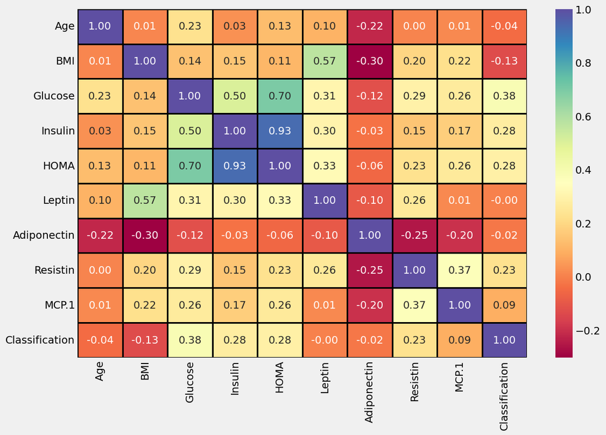

```
----------------------------------------------------------------------------------------------------
DataFrame Pairplot:
```

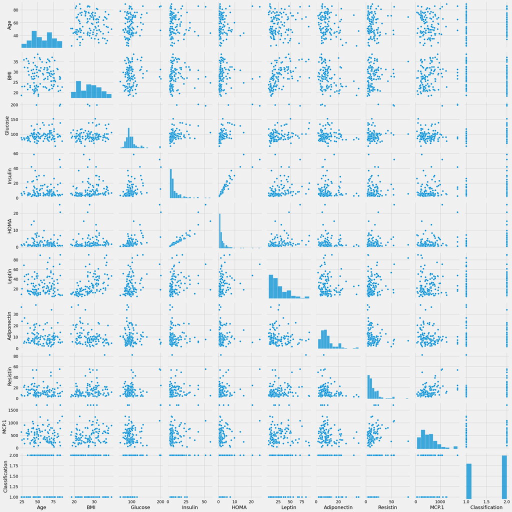

```
----------------------------------------------------------------------------------------------------
Histogram(s) & Boxplot(s):
```

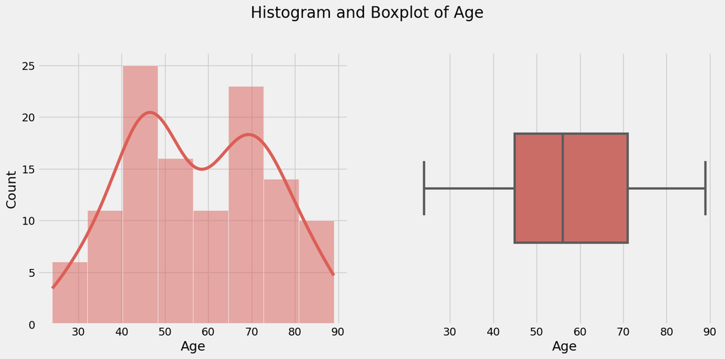

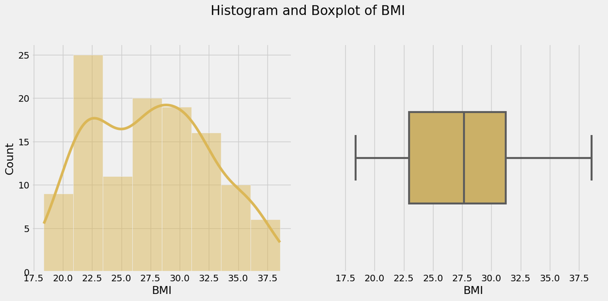

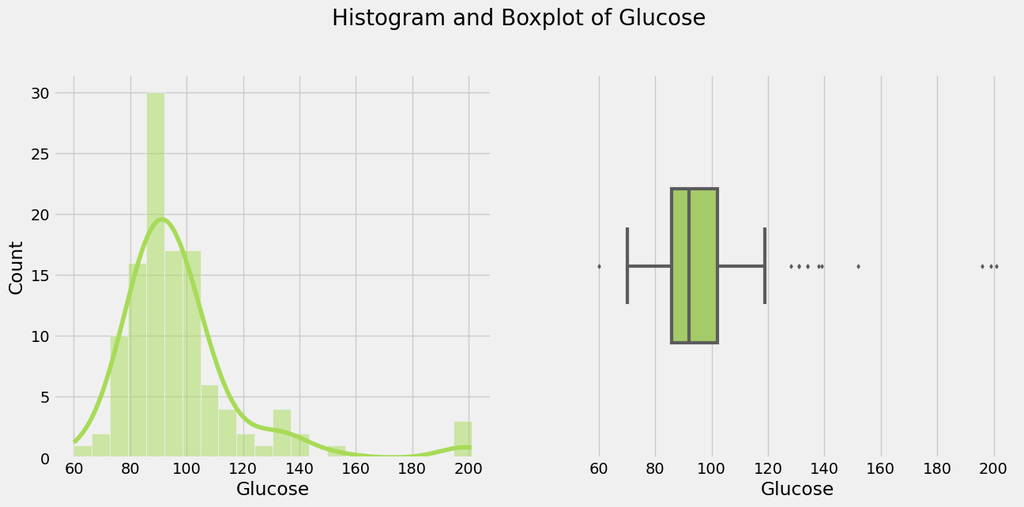

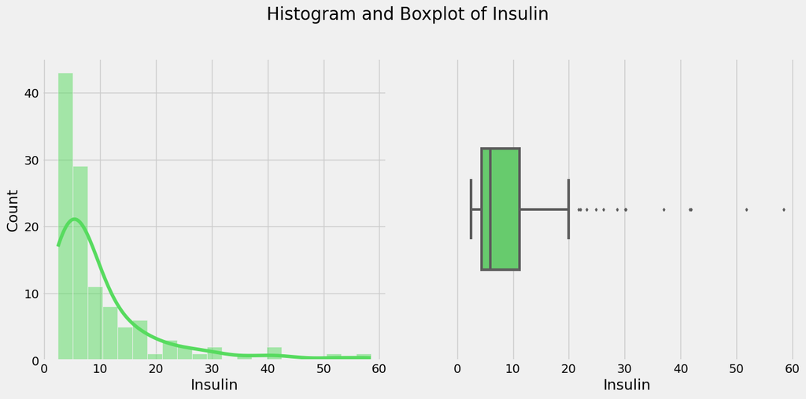

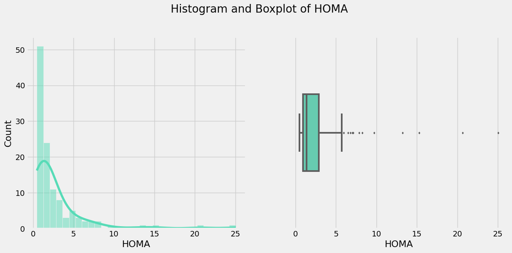

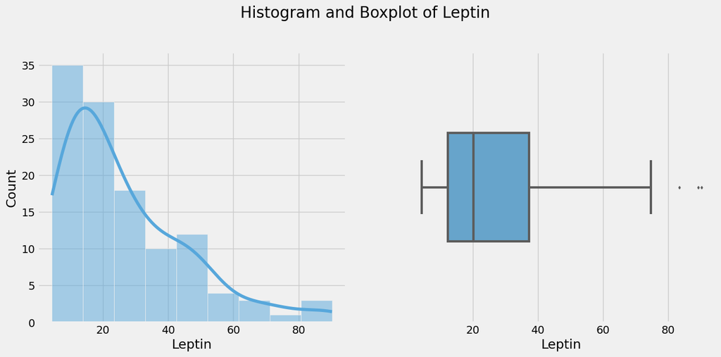

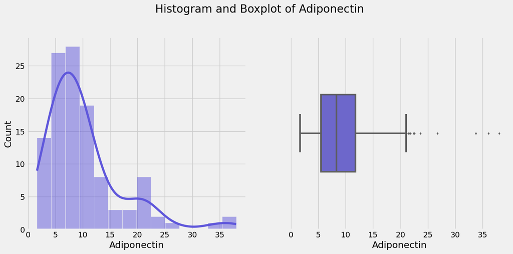

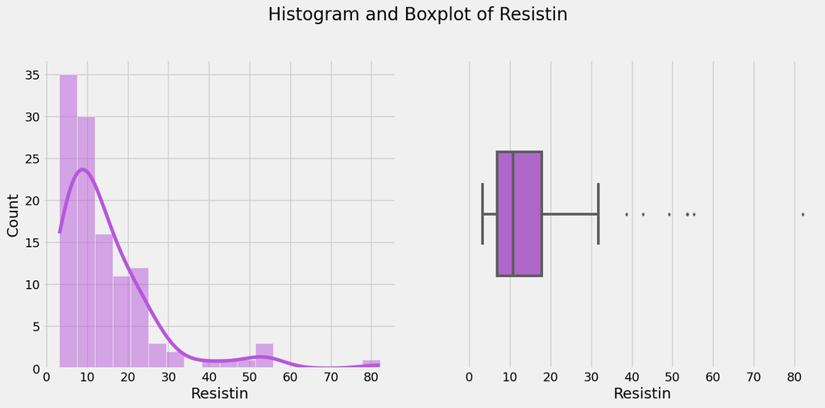

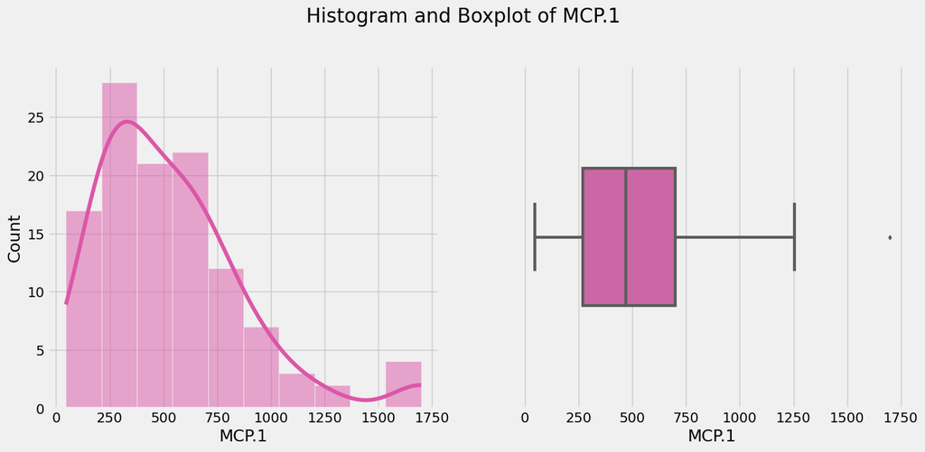

```
----------------------------------------------------------------------------------------------------
Countplot(s):
```

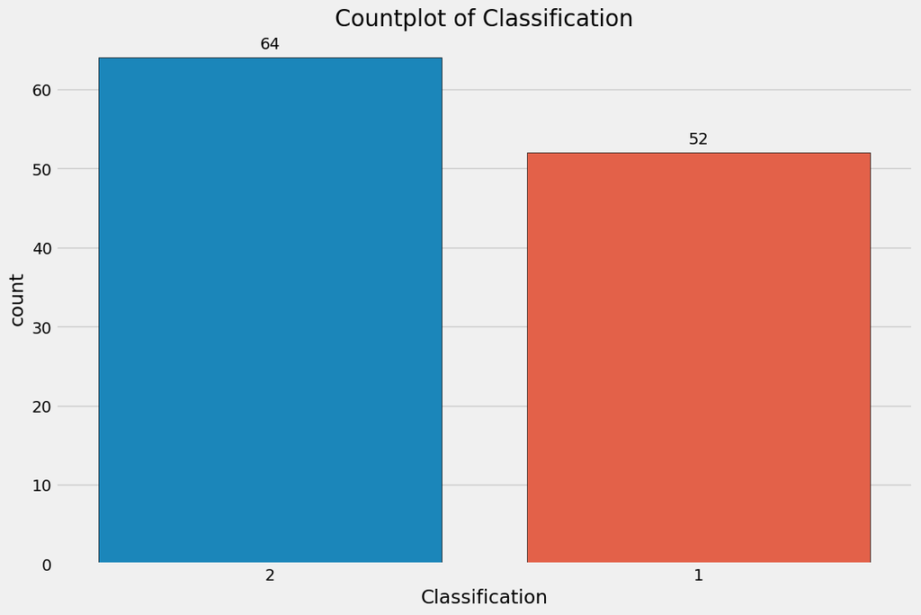

```python
!pip install fasteda
from fasteda import fast_eda
# quick overview of the dataset using fast_eda() function from fasteda module
fast_eda(df)
```

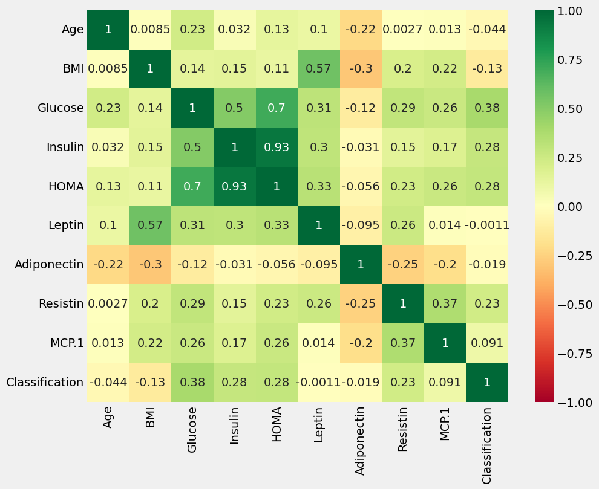

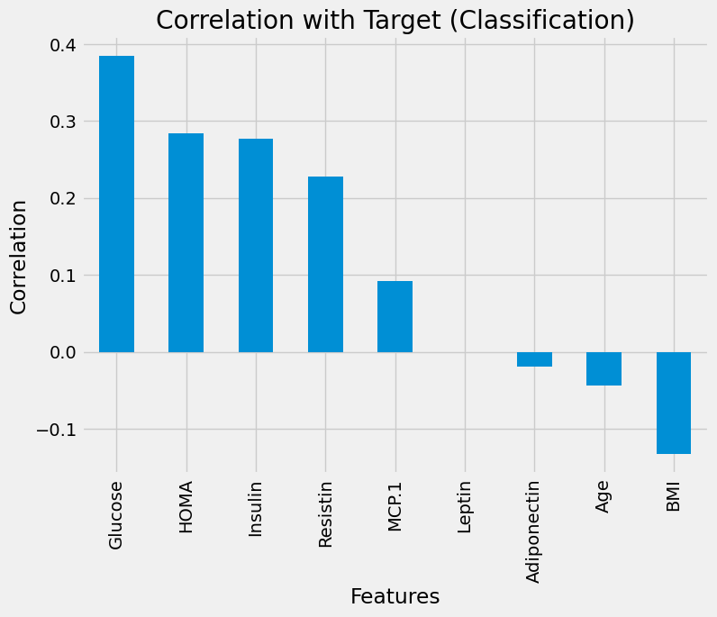

```python
# check for the correlation of the data

plt.figure(figsize=(10,8))
cor = cdf.corr()
sns.heatmap(cor, annot=True,
            cmap=plt.cm.RdYlGn, vmin=-1, vmax=1)
plt.show()

# Visualize the correlation of features with the target column
correlation_with_target = cdf.corr()['Classification'].sort_values(ascending=False)

# Remove correlation with itself
correlation_with_target = correlation_with_target.drop('Classification')

plt.figure(figsize=(8, 6))
correlation_with_target.plot(kind='bar')
plt.title('Correlation with Target (Classification)')
plt.xlabel('Features')
plt.ylabel('Correlation')
plt.show()
```

(Glucose, HOMA, Insullin and Resistin) have high positive correlation with the 'classification' column and BMI have the highiest negative correlation

as we can see we have high correlation between HOMA and Insulin feature Solution: we can omit one of the features 'but we can use PCA instead foe feature extraction in the following sections'

```python
sns.pairplot(df, hue = 'Classification', palette = 'rainbow', diag_kind = "hist" );
```

[output not shown]

[output not shown]

[output cut: 20 more lines]

Currently there do not seem to be two features that separate the data well

```python
cdf['Classification'] = cdf['Classification'].replace({1: 0, 2: 1})
cdf['Classification'] = cdf['Classification'].replace({0: 1, 1: 0})

X = cdf.drop('Classification',axis=1)
y = cdf['Classification']
```

# part 1 - Attempting to reproduce the article we read

In this section we will try to reproduce the results of the article. In the article, they used the same data set and the KNN algorithm with 7 neighbors on the pixels: resistin, glucose, age and BMI and got the following results:

- Accuracy -> 87.50%
- Sensitivity -> 84.62%
- Specificity -> 91.00%
- AUC -> 87.76
- Confusion Matrix:

[[ 11 1]

[ 2 10]]

```python
X_artcl= X[['Age', 'BMI', 'Glucose','Resistin']]
X_train, X_test, y_train, y_test = train_test_split(X_artcl,y,test_size=0.2,random_state=42 ,shuffle=True)
```

```python
# Define the number of neighbors
n_neighbors = 7

# Initialize the k-NN classifier with the specified number of neighbors and parallel processing
knn = KNeighborsClassifier(n_neighbors=n_neighbors, n_jobs=-1)

# Fit the classifier to the training data
knn.fit(X_train, y_train)

# Predict the classes for training and test data
y_train_predicted = knn.predict(X_train)
y_test_predicted = knn.predict(X_test)
```

```python
def calculate_specificity(conf_matrix):
    true_negatives = conf_matrix[0, 0]
    false_positives = conf_matrix[0, 1]
    specificity = true_negatives / (true_negatives + false_positives)
    return specificity
```

```python
# Calculate evaluation metrics for the training set
knn_train_accuracy_score = accuracy_score(y_train, y_train_predicted)
knn_train_precision_score = precision_score(y_train, y_train_predicted)
knn_train_recall_score = recall_score(y_train, y_train_predicted)
knn_train_f1_score = f1_score(y_train, y_train_predicted)
knn_train_conf_matrix = confusion_matrix(y_train, y_train_predicted)
knn_train_auc_score = roc_auc_score(y_train, y_train_predicted)
knn_train_specificity_score = calculate_specificity(knn_train_conf_matrix)


# Calculate evaluation metrics for the test set
knn_test_accuracy_score = accuracy_score(y_test, y_test_predicted)
knn_test_precision_score = precision_score(y_test, y_test_predicted)
knn_test_recall_score = recall_score(y_test, y_test_predicted)
knn_test_f1_score = f1_score(y_test, y_test_predicted)
knn_test_conf_matrix = confusion_matrix(y_test, y_test_predicted)
knn_test_auc_score = roc_auc_score(y_test, y_test_predicted)
knn_test_specificity_score = calculate_specificity(knn_test_conf_matrix)


# Print evaluation metrics for the training set
print("Training Set Evaluation Metrics:")
print("Accuracy Score:", knn_train_accuracy_score)
print("Precision Score:", knn_train_precision_score)
print("Recall Score:", knn_train_recall_score)
print("F1 Score:", knn_train_f1_score)
print("AUC Score:", knn_train_auc_score)
print("Specificity Score:", knn_train_specificity_score)
print("Confusion Matrix:")
print(knn_train_conf_matrix)
print("------------------------------------------------------")

# Print evaluation metrics for the test set
print("Test Set Evaluation Metrics:")
print("Accuracy Score:", knn_test_accuracy_score)
print("Precision Score:", knn_test_precision_score)
print("Recall Score:", knn_test_recall_score)
print("F1 Score:", knn_test_f1_score)
print("AUC Score:", knn_test_auc_score)
print("Specificity Score:", knn_test_specificity_score)
print("Confusion Matrix:")
print(knn_test_conf_matrix)
```

```
Training Set Evaluation Metrics:
Accuracy Score: 0.8260869565217391
Precision Score: 0.8529411764705882
Recall Score: 0.725
F1 Score: 0.7837837837837837
AUC Score: 0.814423076923077
Specificity Score: 0.9038461538461539
Confusion Matrix:
[[47  5]
 [11 29]]
------------------------------------------------------
Test Set Evaluation Metrics:
Accuracy Score: 0.8333333333333334
Precision Score: 0.9
Recall Score: 0.75
F1 Score: 0.8181818181818182
AUC Score: 0.8333333333333333
Specificity Score: 0.9166666666666666
Confusion Matrix:
[[11  1]
 [ 3  9]]
```

As you can see, our results are a little different from the results of the article.

# part 2 - Attempt to improve the results by performing PCA

**PCA** is a dimensionality reduction technique used to transform large datasets into smaller ones while retaining most of the original information. It works by creating new variables, called principal components, which are linear combinations of the original variables. These components capture the maximum variance in the data, making them more interpretable and easier to visualize. PCA helps simplify data analysis by reducing the number of variables, making it faster and more efficient for machine learning algorithms. While the principal components themselves may not have direct interpretability, they provide valuable insights into the underlying structure of the data. PCA aims to preserve as much information as possible while reducing dimensionality, leading to improved data exploration and analysis.

**The method works in five main stages:**

1. Standardization: The range of values of each variable is adjusted so that they all have a mean of 0 and a variance of 1.
2. The covariance matrix: calculated to identify relationships (correlations) between the variables.
3. Eigenvectors and eigenvalues of the covariance matrix: calculated to find the principal components.
4. Feature vector: decides which primary components to use.
5. Transformation: the data is adjusted to the new axes created by the main components

```python
# Define the features you want to analyze using PCA
features = ['Age', 'BMI', 'Glucose', 'Insulin', 'HOMA', 'Leptin', 'Adiponectin',
            'Resistin', 'MCP.1']

# Extract the features you defined earlier
X_f = cdf[features]

# Normalize the features to have a mean of 0 and a standard deviation of 1
# This helps PCA work better with features on different scales
scaler = StandardScaler()
X_norm = scaler.fit_transform(X_f.to_numpy())

# Perform PCA on the normalized features
# This will reduce the dimensionality of your data while preserving most of the information
pca = PCA()
X_pca = pca.fit_transform(X_norm)

# Convert the PCA transformed data to a DataFrame for easier manipulation
names = [f"PC{i+1}" for i in range(X_pca.shape[1])]  # Create column names for PCA components
X_pcadf = pd.DataFrame(X_pca, columns=names)

# Print the first few rows of the PCA DataFrame to see the transformed data
print("First few rows of the PCA DataFrame:")
print(X_pcadf.head())
print("------------------------------------------------------------------------")

# Print the shape of the PCA DataFrame to see the new dimensionality
print("Shape of the PCA DataFrame:")
print(X_pcadf.shape)
```

```
First few rows of the PCA DataFrame:
        PC1       PC2       PC3       PC4       PC5       PC6       PC7  \
0 -1.992785  0.125612  0.362869  0.274120 -0.492652  0.344671 -0.278678
1 -1.328830  0.247930  1.336740 -1.894392 -0.175358 -0.085983 -0.084350
2 -1.217244  0.992393  0.363065 -0.913672  1.314762 -1.387647 -0.547082
3 -1.199203 -0.272409  1.759583 -0.271717 -0.162707 -0.501004 -0.650166
4 -0.898467 -0.143089  2.019185 -1.579261 -0.033842 -0.449444 -0.350436

        PC8       PC9
0 -0.199885  0.250020
1 -0.440901 -0.018887
2  0.156794 -0.044341
3 -0.739578  0.048572
4 -0.449584 -0.070410
------------------------------------------------------------------------
Shape of the PCA DataFrame:
(116, 9)
```

```python
X_train, X_test, y_train, y_test = train_test_split(X_pca,y,test_size=0.2,random_state=42 ,shuffle=True)
```

**We will run the PCA results on KNN with a different number of vandevador if there is an improvement in the results**

```python
# Define the range of n_neighbors values to test
n_neighbors_values = [3, 5, 7, 9]

# Initialize lists to store evaluation metrics for each n_neighbors value
train_accuracy_scores = []
test_accuracy_scores = []
train_precision_scores = []
test_precision_scores = []
train_recall_scores = []
test_recall_scores = []
train_f1_scores = []
test_f1_scores = []
train_conf_matrices = []
test_conf_matrices = []

# Loop over different values of n_neighbors
for n_neighbors in n_neighbors_values:
    # Create and fit the k-NN classifier
    knn = KNeighborsClassifier(n_neighbors=n_neighbors, n_jobs=-1)
    knn.fit(X_train, y_train)

    # Predictions on training and test sets
    y_train_predicted = knn.predict(X_train)
    y_test_predicted = knn.predict(X_test)

    # Compute evaluation metrics for the training set
    train_accuracy_scores.append(accuracy_score(y_train, y_train_predicted))
    train_precision_scores.append(precision_score(y_train, y_train_predicted))
    train_recall_scores.append(recall_score(y_train, y_train_predicted))
    train_f1_scores.append(f1_score(y_train, y_train_predicted))
    train_conf_matrices.append(confusion_matrix(y_train, y_train_predicted))

    # Compute evaluation metrics for the test set
    test_accuracy_scores.append(accuracy_score(y_test, y_test_predicted))
    test_precision_scores.append(precision_score(y_test, y_test_predicted))
    test_recall_scores.append(recall_score(y_test, y_test_predicted))
    test_f1_scores.append(f1_score(y_test, y_test_predicted))
    test_conf_matrices.append(confusion_matrix(y_test, y_test_predicted))

# Print evaluation metrics for each value of n_neighbors
for i, n_neighbors in enumerate(n_neighbors_values):
    print(f"n_neighbors = {n_neighbors}:")
    print("Training Set Evaluation Metrics:")
    print("Accuracy Score:", train_accuracy_scores[i])
    print("Precision Score:", train_precision_scores[i])
    print("Recall Score:", train_recall_scores[i])
    print("F1 Score:", train_f1_scores[i])
    print("Confusion Matrix:")
    print(train_conf_matrices[i])
    print("------------------------------------------------------")
    print("Test Set Evaluation Metrics:")
    print("Accuracy Score:", test_accuracy_scores[i])
    print("Precision Score:", test_precision_scores[i])
    print("Recall Score:", test_recall_scores[i])
    print("F1 Score:", test_f1_scores[i])
    print("Confusion Matrix:")
    print(test_conf_matrices[i])
    print("======================================================")
```

```
n_neighbors = 3:
Training Set Evaluation Metrics:
Accuracy Score: 0.782608695652174
Precision Score: 0.7631578947368421
Recall Score: 0.725
F1 Score: 0.7435897435897436
Confusion Matrix:
[[43  9]
 [11 29]]
------------------------------------------------------
Test Set Evaluation Metrics:
Accuracy Score: 0.8333333333333334
Precision Score: 0.7857142857142857
Recall Score: 0.9166666666666666
F1 Score: 0.8461538461538461
Confusion Matrix:
[[ 9  3]
 [ 1 11]]
======================================================
n_neighbors = 5:
Training Set Evaluation Metrics:
Accuracy Score: 0.8152173913043478
Precision Score: 0.7804878048780488
Recall Score: 0.8
F1 Score: 0.7901234567901235
Confusion Matrix:
[[43  9]
 [ 8 32]]
------------------------------------------------------
Test Set Evaluation Metrics:
Accuracy Score: 0.8333333333333334
Precision Score: 0.7857142857142857
Recall Score: 0.9166666666666666
F1 Score: 0.8461538461538461
Confusion Matrix:
[[ 9  3]
 [ 1 11]]
======================================================
n_neighbors = 7:
Training Set Evaluation Metrics:
```

[output cut: 21 more lines]

```
Recall Score: 0.625
F1 Score: 0.6756756756756757
Confusion Matrix:
[[43  9]
 [15 25]]
------------------------------------------------------
Test Set Evaluation Metrics:
Accuracy Score: 0.75
Precision Score: 0.8
Recall Score: 0.6666666666666666
F1 Score: 0.7272727272727272
Confusion Matrix:
[[10  2]
 [ 4  8]]
======================================================
```